# Bruhn_A20_2

表 A20.4 の修正された面積を用いて、真のストリンガー荷重を求めるためには、真のストリンガー面積を使用する必要があり、これは剪断流解析で使用されなければならない。

## A20.6 胴体構造の剪断流解析

胴体の有効断面積が得られれば、剪断流解析を行うことができる。手順は、第 A19 章で翼構造について説明したものと同様である。説明のために、2つの例題を提示する。

### 例題1. 対称テーパ断面

図 A20.6 は、小型飛行機の胴体後部を代表するような、テーパのついた円形の胴体構造の一部を示している。この例題は剪断流解析を説明することのみを目的としているため、16本のストリンガーのみが有効な部材であると仮定する。実際の応力解析では、前節 A20.3 から A20.5 で説明したように、有効な断面積を使用する必要がある。

問題は、図 A20.6 に示すように、ステーション（150）における与えられた荷重状態の下で、ステーション（0）におけるストリンガー応力と外板剪断流応力分布を決定することである。

### 解法 No. 1 - 1つの断面のみの梁特性を考慮することによる解法

縦方向のストリンガーまたはフランジ材料の変化がかなり均一である場合、この方法は、結果として得られる剪断流応力にほとんど誤差を生じることなく使用できる。

ステーション（0）における断面の主軸 Y に関する慣性モーメント：

$$I_y = (15^2 \times .1 \times 2) + (13.86^2 + 10.61^2 + 5.74^2) \times .1
\times 4 = 180 \text{ in.}^4$$

表 A20.5 は、フランジの曲げ応力と、セル外板によって負担される純全剪断荷重を決定するために必要な計算を示している。セルにはテーパがついているため、ストリンガーは $z$ 方向の分力を持ち、したがってストリンガーの軸力は外力としての剪断荷重に抵抗するのを助ける。表 A20.5 の列 (8) の総和は、胴体半断面の総和として $-333.4$ lb. となる。

したがって、ステーション 0 における純ウェブ剪断荷重は以下に等しい：

$$V_{\text{web}} = V_{\text{ext}} + V_{\text{flange}} = 2000 + (2 \times
-333.4) = 1333.2 \text{ lb.}$$

この特定の問題における結果は、ステーション 0 においてフランジ・ストリンガーシステムが外部剪断荷重の3分の1に抵抗することを示している。ステーション 150 では、ストリンガーの荷重がゼロであるため、ウェブシステムが 2000 lb. の外部剪断荷重全体に抵抗する。

実際の設計では、多くの場合、必要とされる板厚が1段階以上薄くなるため、純ウェブ剪断荷重を使用すべきである。

### 撓み剪断流の計算

$$q = q_o - \frac{V_z(\text{web}) \sum a z}{I_y} = q_o -
\frac{1333.2}{180} \sum a z = q_o - 7.40 \sum a z \quad \text{--- (A)}$$

断面が Z 軸に関して対称であるため、中心線上におけるウェブの撓み剪断流はゼロである。したがって、 $q_o$ はゼロとみなされ、式 (A) の総和はストリンガー (1) から開始される。

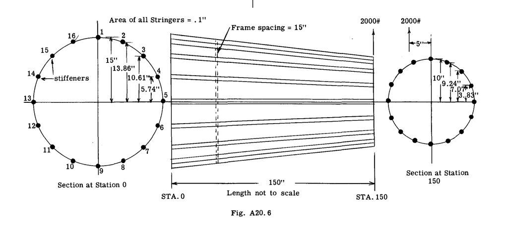

図 A20.6

$$q_{12} = 0 - 7.40 \times .05 \times 15 = -5.55 \text{ lb./in.}$$

$$q_{23} = -5.55 - 7.40 \times .1 \times 13.86 = -15.80 \text{ lb./in.}$$

$$q_{34} = -15.80 - 7.40 \times .1 \times 10.61 = -23.66 \text{ lb./in.}$$

$$q_{45} = -23.66 - 7.40 \times .1 \times 5.74 = -27.91 \text{ lb./in.}$$

ステーション（0）における断面の図心まわりのねじりモーメント $T$ は、 $5 \times 2000 = 10000$ in. lb.（ステーション 150 方向を向いて時計回り）に等しい。ステーション 0 における断面の対称性により、ストリンガー荷重の面内分力は断面図心のまわりにモーメントを生じない。

平衡状態を保つためには、 $\sum M_x = 0$ とするために一定の内部剪断流 $q_1$ が必要である。

$$q_1 = \frac{T}{2A} = \frac{-10000}{2 \times \pi \times 15^2} = -7.06
\text{ lb./in.}$$

撓み剪断流 $q$ にねじり剪断流 $q_1$ を加えると、以下の結果が得られる：

$$q_{12} = -7.06 - 5.55 = -12.61 \text{ lb./in.}$$

$$q_{23} = -7.06 - 15.80 = -22.86 \text{ lb./in.}$$

$$q_{34} = -7.06 - 23.66 = -30.72 \text{ lb./in.}$$

$$q_{45} = -7.06 - 27.91 = -34.97 \text{ lb./in. など}$$

図 A20.7 は、その結果をグラフ形式で示している。断面の左側では剪断力が同じ符号であるため、それらは互いに足し合わされる。

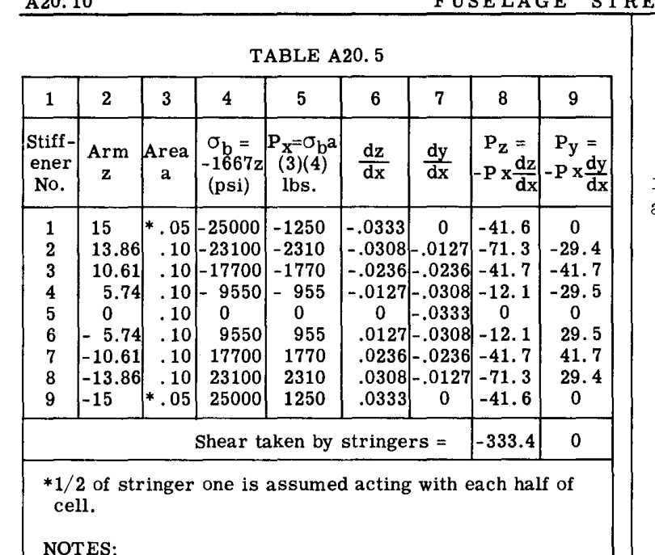

TABLE A20.5

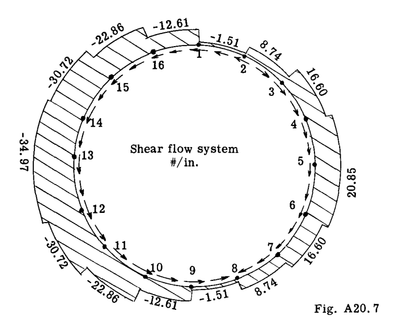

図 A20.7

### 解法 No. 2. 隣接するステーション間のストリンガー荷重の変化による剪断流。 $\Delta P$ 法。

剪断流は、ステーション（0）と（30）の胴体断面間の縦方向ストリンガーにおける軸力変化を考慮することによって計算される。

図 A20.8 は、ステーション 30 における梁断面を示しており、ストリンガー面積はステーション 0 と同じであるが、セルのテーパのために断面全体としては小さくなっている。

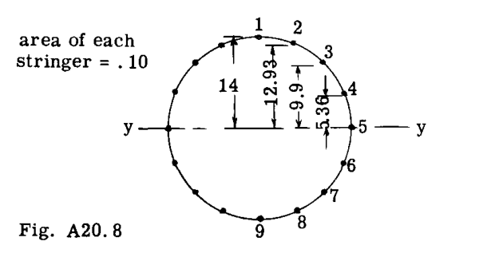

図 A20.8

表 A20.6 は、撓み剪断システムに関する計算を示している。手順は、第 A19 章で翼構造について説明したものと同様である。

列 13 の結果を解法 No. 1 で求められた撓み剪断流と比較すると、2番目の解法では最大剪断流が 28.95 lb./in. となり、最初の解法における値 27.91 に対する差が生じることがわかる。最初の方法は1つの断面のみの特性を扱っており、これには剪断流に対する慣性モーメントの変化の影響を含めることができない。したがって、実用的な解析手順としては2番目の方法が推奨される。

断面は対称であるため、ステーション 0 におけるストリンガー力の面内分力によって誘起されるモーメントは存在しない。

ねじり剪断流の力は解法 No. 1 と同じであり、これらは表 A20.6 の列 13 の値に加えられ、図 A20.7 と同様のパターンを与える。

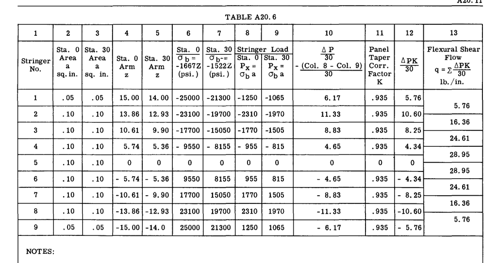

TABLE A20.6

## A20.7 例題。不均等なストリンガー面積を持つテーパ円形胴体

実際の胴体にはドアなどの切り欠きがあるため、胴体の横断面はストリンガーや外板面積に関してすべてが対称であるとは限らない。非対称なケースを説明するために、単純化したケースを提示する。

図 A20.9 は、テーパのついた胴体の一部を示している。ストリンガー面積は、曲げ材料に対して横断面が非対称になるようなものである。ここでも単純化のために、ストリンガーが唯一の有効な部材であると仮定する。実際の設計実務では、外板および各ストリンガーの有効性は、節 A20.4 および A20.5 で説明したように考慮される必要がある。

問題は、図 A20.9 に示すように、ステーション（150）に作用する $P_z = 4000$ lb.、 $P_y = 1000$ lb.、および $P_x = 1500$ の外部荷重による、ステーション（0）におけるストリンガー応力と外板剪断流の値を決定することである。

### 解法：

ステーション（0）における剪断流システムを求めるために $\Delta P$ 法を使用することを選択したため、2つのステーション、すなわちステーション（0）とステーション（30）におけるストリンガー荷重を求める。最初のステップは、主軸 $z$ および $y$ まわりの各胴体断面の慣性モーメントと、これらの軸に関する相乗モーメントを求めることである。表 A20.7（列1から11）は、ステーション（0）の断面特性の計算を示している。表 A20.8 は、ステーション（30）に関する同様の計算を示している。

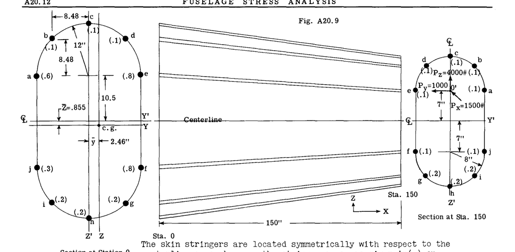

図 A20.9

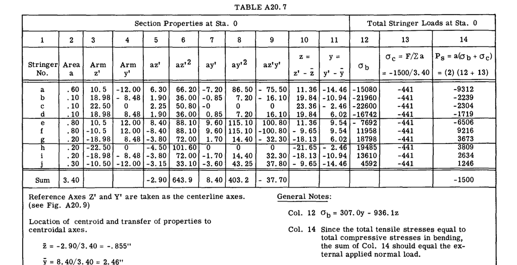

TABLE A20.7

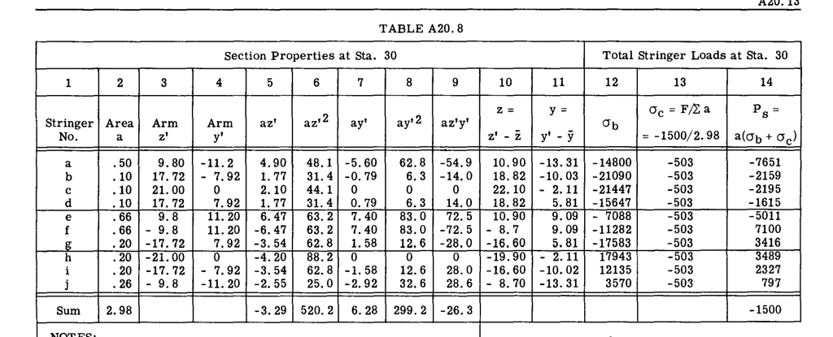

TABLE A20.8

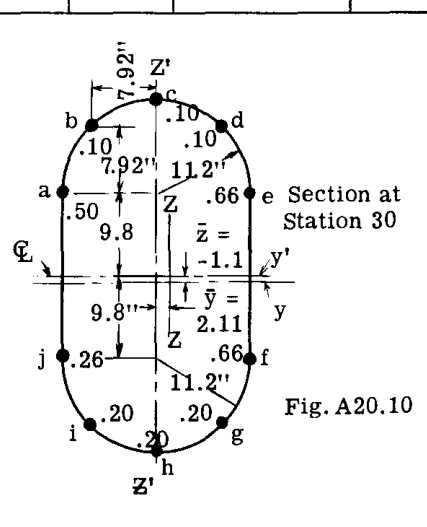

図 A20.10

曲げ応力と剪断応力を計算する前に、ステーション（0）と（30）における外部曲げモーメント、剪断力、および法線力を知る必要がある。

ステーション（0）において：

ステーション（0）における $y$ 中立軸まわりの曲げモーメントは、

$$M_y = P_z (150) + P_x (7.85) = 4000 \times 150 + 1500 \times 7.85 =
611800 \text{ in. lb.}$$

$$M_z = P_y (150) - P_x (2.46) = -1000 \times 150 + 1500 \times 2.46 =
-146310 \text{ in. lb.}$$

ステーション（0）における剪断力は、 $V_z = P_z = 4000$ lb.、および $V_y = P_y = -1000$ lb. である。

断面図心に関連するステーション（0）における法線力 $P_n$ は、 $\sum P_x = -1500$ lb. に等しい。

同様の方法で、ステーション（30）における値は、（図 A20.10 参照）

$$M_y = 4000 \times 120 + 1500 \times 8.10 = 492150 \text{ in. lb.}$$

$$P_n = -1500 \text{ lb.}, \quad V_z = 4000 \text{ lb.}, \quad V_y = -1000
\text{ lb.}$$

### 曲げ応力の計算

ステーション（0）：

$$\sigma_b = -(K_3 M_z - K_1 M_y) y - (K_2 M_y - K_1 M_z) z$$

ここで、

$$K_1 = \frac{I_{yz}}{I_y I_z - I_{yz}^2}$$

$$K_2 = \frac{I_z}{I_y I_z - I_{yz}^2}$$

$$K_3 = \frac{I_y}{I_y I_z - I_{yz}^2}$$

表 A20.7 および A20.8 からの値を代入する：

$$K_1 = -30.55 / (641.4 \times 382.6 - 30.55^2) = -30.55 / 244670 =
-.0001248$$

$$K_2 = 382.6 / 244670 = .00156$$

$$K_3 = 641.4 / 244670 = .00262$$

$\sigma_b$ の式に $K$ 値を代入する：

$$\sigma_b = - [.00262 \times -146310 - (-.0001248 \times 611800)] y -
[.00156 \times 611800 - (-.0001248 \times -146310)] z$$

したがって、

$$\sigma_b = 307.0 y - 936.1 z \quad (\text{正の } \sigma_b \text{
は引張})$$

ステーション（30）：

$$K_1 = -19.4 / (516.6 \times 286 - 19.4^2) = -19.4 / 147620 = -.0001315$$

$$K_2 = 286 / 147620 = .001936$$

$$K_3 = 516.6 / 147620 = .0035$$

$$\sigma_b = - [.0035 \times -116800 - (-.0001315 \times 492150)] y -
[.001936 \times 492150 - (-.0001315 \times 116820)] z$$

したがって、

$$\sigma_b = 344.3 y - 937.7 z$$

表 A20.7 および A20.8 の列 (12) は、 $\sigma_b$ の方程式を解いた結果を示している。

1500 lb. の外部荷重がセクションに対して垂直に、かつセクションの図心を通って作用するため、セクションには一様な圧縮応力 $\sigma_c$ が生じる（列 13 参照）。各ストリンガーにおける全荷重 $P_s$ は、ストリンガーの面積に曲げ応力と軸応力の和を掛けたものに等しい（各表の列 14 参照）。

### 撓み剪断流 $q$ の計算

表 A20.9 は、ステーション（0）と（30）の間のストリンガー荷重の変化に基づいて、ステーション（0）における剪断流を決定するために必要な計算を示している。例題1、表 A20.6、列 (11) で行われたような、外板パネルのテーパによる平均剪断力の補正は、安全側の結果を与える傾向があるため、この解法では省略されている。有効断面積が非対称であるため、任意の点における撓み剪断流 $q$ の値は未知であり、したがってある点における $q$ の値が仮定される。表 A20.9 では、ウェブ $aj$ における剪断流 $q$ はゼロと仮定されている。列 (5) は、この仮定の下での他の点における結果を示している。

### 中心線軸の交点まわりの剪断流のモーメント

ステーション（0）における横断面内での平衡のために、すべての内部力と外部力の面内モーメントの和はゼロでなければならない。表 A20.9 の列 (7) は、この点まわりの撓み剪断によるモーメントを示している（説明については、表の下の注記と図を参照）。

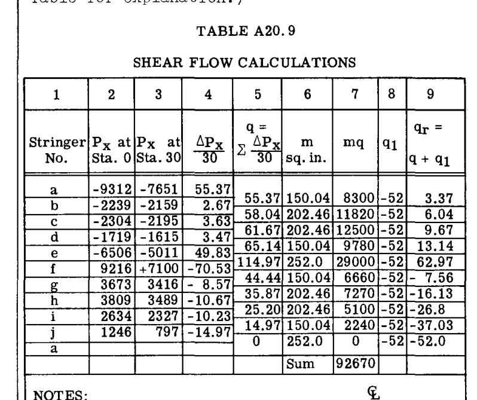

TABLE A20.9

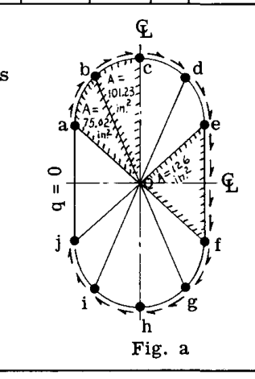

図 a

### ストリンガー荷重の面内分力によるモーメント

ステーション（0）においてストリンガーは断面に対して垂直ではないため、ストリンガーには、モーメント中心として選択された対称軸の交点まわりにモーメントを発生させる可能性のある面内分力が存在する。表 A20.10 は、面内分力とモーメント中心 $O'$ まわりのそれらのモーメントの計算を示している。

### 外部荷重システムの点（0’）まわりのモーメント

$Y$ 方向に作用するステーション（150）における 1000 lb. の荷重は、ステーション（0）の点 $O'$ まわりに 7” のモーメントアームを持つ。

したがって、外部モーメント $= 1000 \times 7 = 7000$ in. lb.

したがって、仮定されたモーメント中心 $O'$ まわりの全モーメントは、

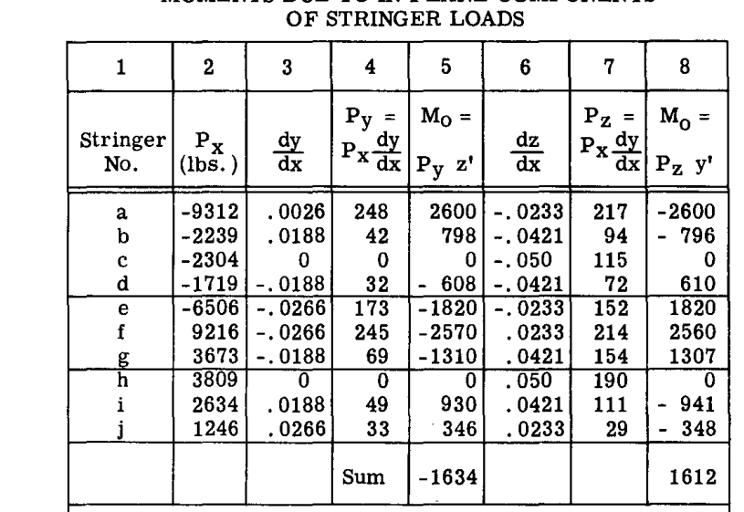

TABLE A20.10

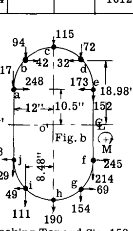

図 b

$$\begin{aligned}
92670 & \quad \text{剪断流 } q \text{ によるもの} \\
-22 & \quad \text{ストリンガーの面内分力によるもの} \\
7000 & \quad \text{外部荷重によるもの}
\end{aligned}$$

$$\text{合計} = 99648 \text{ in. lb.}$$

したがって、平衡のためには、セルのまわりに一定の剪断流 $q_1$ を加えることによって提供できる $-99646$ のモーメントが必要となる：

$$q_1 = \frac{T}{2A} = \frac{-99648}{2 \times 957} = -52 \text{ lb./in.}
\quad (957 = \text{セルの囲む面積})$$

この $q$ の値は表 A20.9 の列 8 に入力される。任意のウェブ部分における結果としての剪断流 $q_r$ は、 $q$ と $q_1$ の代数和に等しい（表 A20.9 の列 9 参照）。図 A20.11 は、その結果をグラフ形式で示している。

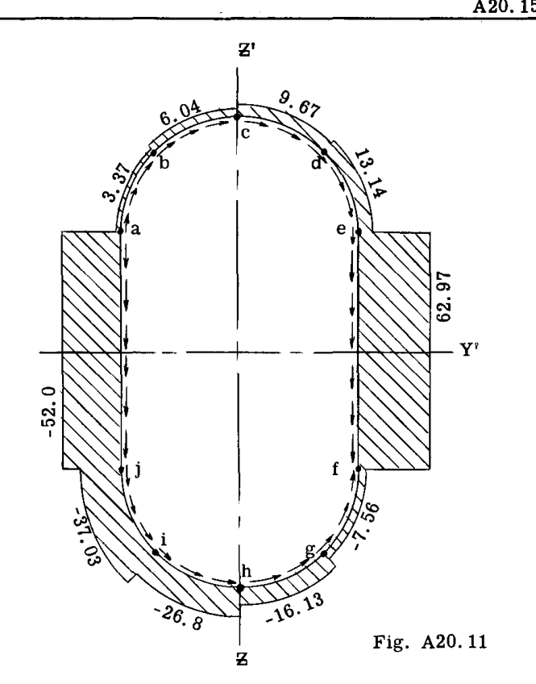

図 A20.11

大きな集中荷重が加えられる不連続部におけるこれらの影響の近似値、および剪断遅れの影響は、第 A19 章の節 18 から 20 に示されている手順によって決定することができる。より厳密な解析は、第 A8 章に示されている基本理論を適用することによって行うことができる。

内部圧力によるシェル応力の問題は第 A16 章に示されている。胴体外板の強度設計は、組合せ応力の問題を伴う。すべての応力状態下における構造要素とその結合部の強度設計という広範な問題は、第 II 巻で扱われている。

## A20.9 問題

### (1)

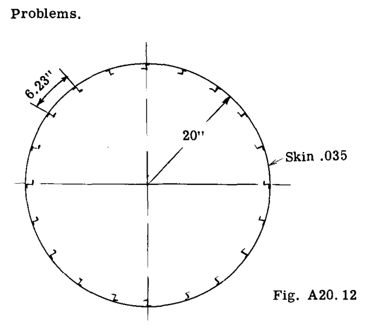

図 A20.12

図 A20.12 は円形胴体の断面を示している。すべてのストリンガーは同じ面積、すなわち 0.12 sq. in. を持つ。外板の厚さは 0.035 インチである。ストリンガーの高さは 1 インチである。材料はすべてアルミニウム合金である。 $E = 10,500,000$ psi。ストリンガーとその有効外板を合わせた極限圧縮強度は 35000 psi である。有効な外板幅には $w = 1.9t(E/\sigma_{\text{ST}})^{\frac{1}{2}}$ を使用せよ。湾曲したパネルの座屈強度には $\sigma_{\text{cr}} = .3 Et/r$ を使用せよ。水平中立軸まわりの曲げに対して胴体断面が発揮する極限曲げモーメントを決定せよ。線形応力分布を使用せよ。節 A20.4 の例題に示されている手順に従え。

### (2)

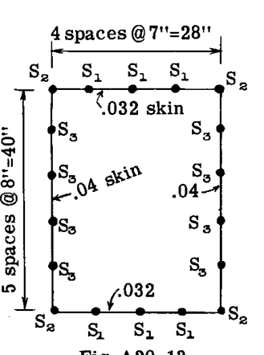

図 A20.13

図 A20.13 は矩形胴体の断面を示している。点はストリンガーの位置を表している。 $S_1$ 、 $S_2$ 、および $S_3$ の3種類のストリンガーが使用されている。図 A20.14 は、3つのストリンガータイプのそれぞれの極限圧縮応力-歪曲線と、材料の引張応力-歪曲線を示している。

最大単位圧縮歪が .008 に制限されている場合、水平中立軸まわりの胴体断面の極限曲げ抵抗を決定せよ。解法については節 A20.5 を参照のこと。

追加データ：ストリンガー $S_1$ の面積 $= .12$ sq.in.、 $S_2 = .25$ sq.in.、 $S_3 = .08$ sq.in.、 $E = 10,500,000$ psi。

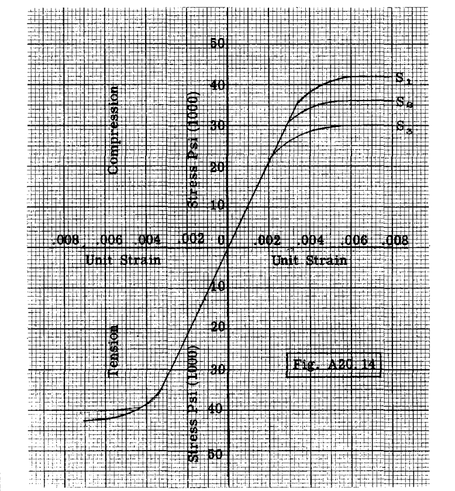

図 A20.14

### (3)

図 A20.15 は、8本のストリンガーを持つテーパ円形胴体を示している。各ストリンガーの面積は 0.1 sq.in. である。ストリンガーがすべての曲げ抵抗を発揮すると仮定せよ。ステーション（0）における $P_z$ および $P_x$ 荷重による、ステーション（110）におけるストリンガーの軸力を求めよ。また、 $\Delta P$ 法を用いてステーション 110 における剪断流システムを求めよ。平均剪断流を得るために、ステーション（90）における特性を使用せよ。

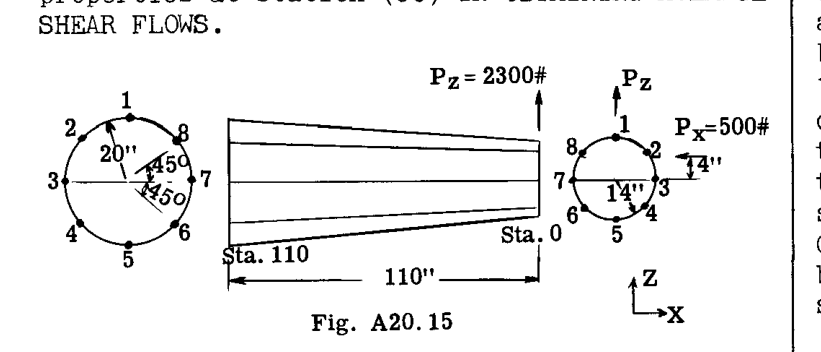

図 A20.15

### (4)

問題(3)と同様であるが、ストリンガー No. (2) の面積を 0.3 sq. in. に変更し、非対称断面とせよ。

## A20.10 胴体ストリンガーおよびリングにおける二次応力

修正された梁理論または第 A8 章のより厳密な理論を使用して、代表的な胴体のストリンガーまたはロンジロンに生じる応力は、**一次応力**と呼ばれる。重量軽減の必要性から、ほとんどの胴体構造は外板の座屈を許容するように設計されており、これは外板の剪断荷重が対角線上の半引張張力場作用によって伝達されることを意味している。外板パネルにおけるこの対角線上の引張力は、ストリンガーおよび胴体リングに追加の応力を発生させる。これらの結果として生じる応力は**二次応力**と呼ばれ、ストリンガーやリングの強度設計において、一次応力に適切に加算されなければならない。第 C11 章は、外板パネルにおける対角線上の半引張張力場作用によるこれらの二次応力について扱っている。翼および胴体の章を学んだ後、外板で覆われた構造物の完全な応力状態を得るために、第 C10 章および第 C11 章を参照することが推奨される。